# Mapa del Área de estudio

Tania Martínez León

2025-10-26

##### El área de estudio se encuentra ubicada en la Sierra Juárez, de Oaxaca, México, dentro del sistema montañoso de la Sierra Madre de Oaxaca, de manera particular en la vertiente Cerro Zacate- Humo Grande. El área de distribución de *Q. macdougalli*i pertenece a los municipios de Santiago Comaltepec e Ixtlán de Juárez. El clima del área de estudio es templado húmedo con lluvias en verano, con una precipitación media anual de 1600 mm y una temperatura media anual de 14 °C (Anacleto-Carmona, 2015).

#### Descripción de las capas a utilizar

##### Para elaborar el mapa de los sitios de muestreo de los datos de Q. macdougallii, se van a ocupar 1 capa ráster (DEM), y cuatro capas vectoriales (polígonos de: México, Oaxaca , distrito de Ixtlán de Juárez y sitios de muestreo) además se creará una nueva capa ráster a partir del DEM.

#### 1. Cargar paquetes necesarios

```r
# Vector de paquetes necesarios
paquetes <- c("ggplot2",    # Visualización de datos
              "sf",         # Archivos vectoriales
              "RColorBrewer", # Paletas de colores
              "terra",      # Maneja archivos raster
              "dbplyr",     # Manipulación de bases de datos
              "cowplot",    # Unión de gráficas
              "ggspatial",  # Rosa, la escala
              "magick",     # Fotos dentro de gráficos
              "patchwork",  # Une gráficas
              "ggnewscale", # Agrega nuevas paletas de colores para sobreponer capas en la composición del mapa
              "tidyterra")  # Sobreponer capa hillshade sobre DEM
# Instalar paquetes si no están instalados
#install.packages(paquetes, dependencies = TRUE)

# Cargar librerias
library(ggplot2)
library(sf)
library(RColorBrewer)
library(terra)
library(dbplyr)
library(cowplot)
library(ggspatial)
library(magick)
library(patchwork)
library(ggnewscale)
library(tidyterra)
```

#### 2. Importar archivos vectoriales

#### 2.1 Cargar la capa de México

```r
Mexico <- st_read("destdv250k_2gw.shp")
dim(Mexico)
```

```
## [1] 33  9
```

```r
names(Mexico)
```

```
## [1] "AREA"       "PERIMETER"  "COV_"       "COV_ID"     "ENTIDAD"
## [6] "CAPITAL"    "RASGO_GEOG" "NUM_EDO"    "geometry"
```

```r
head(Mexico)
```

```
## Simple feature collection with 6 features and 8 fields
## Geometry type: POLYGON
## Dimension:     XY
## Bounding box:  xmin: -117.1258 ymin: 22.8716 xmax: -98.42263 ymax: 32.71873
## Geodetic CRS:  WGS 84
##        AREA PERIMETER COV_ COV_ID              ENTIDAD    CAPITAL RASGO_GEOG
## 1  6.710632  22.08149    2      1      BAJA CALIFORNIA   Mexicali       <NA>
## 2 16.687178  36.64233    3      2               SONORA Hermosillo       <NA>
## 3 22.876678  29.93474    9      8            CHIHUAHUA  Chihuahua       <NA>
## 4 13.817569  23.80115   18     17 COAHUILA DE ZARAGOZA   Saltillo       <NA>
## 5  6.369806  36.67640   92     91  BAJA CALIFORNIA SUR     La Paz       <NA>
## 6  5.769290  19.33190  139    138           NUEVO LEON  Monterrey       <NA>
##   NUM_EDO                       geometry
## 1      02 POLYGON ((-116.152 32.61459...
## 2      26 POLYGON ((-114.8136 32.4945...
## 3      08 POLYGON ((-108.7545 31.3346...
## 4      05 POLYGON ((-102.6741 29.7445...
## 5      03 POLYGON ((-112.765 28.00025...
## 6      19 POLYGON ((-99.84312 27.7708...
```

```r
class(Mexico)
```

```
## [1] "sf"         "data.frame"
```

#### 2.2 cargar capa de Oaxaca

```r
oaxaca <- st_read("oaxaca.shp")
dim(oaxaca)
```

```
## [1] 1 9
```

```r
names(oaxaca)
```

```
## [1] "CVE_ENT"   "NOM_ENT"   "CVE_CAP"   "NOM_CAP"   "COV_"      "COV_ID"
## [7] "AREA"      "PERIMETER" "geometry"
```

```r
head(oaxaca)
```

```
## Simple feature collection with 1 feature and 8 fields
## Geometry type: MULTIPOLYGON
## Dimension:     XY
## Bounding box:  xmin: 2869217 ymin: 419386.6 xmax: 3365490 ymax: 752190.1
## Projected CRS: WGS_1984_Lambert_Conformal_Conic
##   CVE_ENT NOM_ENT CVE_CAP          NOM_CAP COV_ COV_ID    AREA PERIMETER
## 1      20  Oaxaca  670001 Oaxaca de Juárez   19     19 9282945  3127.837
##                         geometry
## 1 MULTIPOLYGON (((3099110 423...
```

```r
class(oaxaca)
```

```
## [1] "sf"         "data.frame"
```

```r
crs(oaxaca, proj = TRUE)
```

```
## [1] "+proj=lcc +lat_0=12 +lon_0=-102 +lat_1=17.5 +lat_2=29.5 +x_0=2500000 +y_0=0 +datum=WGS84 +units=m +no_defs"
```

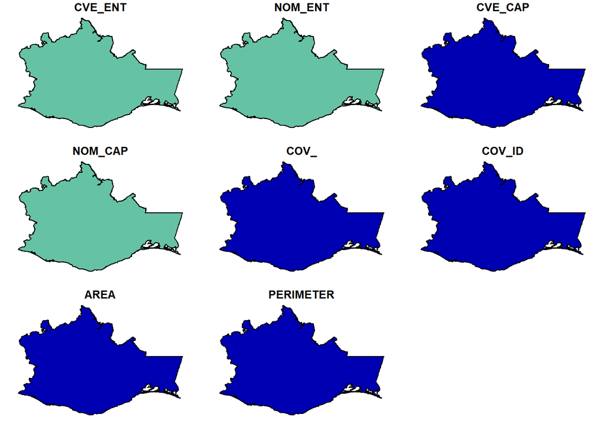

```r
plot(oaxaca)
```

#### 2.3 Cargar capa con los municipios del distrito de Ixtlán

```r
ixtlan <- st_read("ixtlan_dis_mun.shp")
dim(ixtlan)
```

```
## [1]  26 163
```

```r
names(ixtlan)
```

```
##   [1] "CVEGEO"   "NOM_ENT"  "NOMBRE"   "POB1"     "POB2"     "POB2_R"
##   [7] "POB3"     "POB3_R"   "POB4"     "POB4_R"   "POB5"     "POB5_R"
##  [13] "POB6"     "POB6_R"   "POB7"     "POB7_R"   "POB8"     "POB8_R"
##  [19] "POB9"     "POB9_R"   "POB10"    "POB10_R"  "POB11"    "POB11_R"
##  [25] "POB12"    "POB12_R"  "POB13"    "POB13_R"  "POB14"    "POB14_R"
##  [31] "POB15"    "POB15_R"  "POB16"    "POB16_R"  "POB17"    "POB17_R"
##  [37] "POB18"    "POB18_R"  "POB19"    "POB19_R"  "POB20"    "POB20_R"
##  [43] "POB21"    "POB21_R"  "POB22"    "POB22_R"  "POB23"    "POB23_R"
##  [49] "POB24"    "POB24_R"  "POB25"    "POB25_R"  "POB26_R"  "POB27_R"
##  [55] "POB28_R"  "POB29_R"  "POB30_R"  "POB31"    "POB31_R"  "POB32"
##  [61] "POB32_R"  "POB33"    "POB33_R"  "POB34"    "POB34_R"  "POB35"
##  [67] "POB35_R"  "POB36"    "POB36_R"  "POB37"    "POB37_R"  "POB38"
##  [73] "POB38_R"  "POB39"    "POB39_R"  "POB40"    "POB40_R"  "POB41"
##  [79] "POB41_R"  "POB42"    "POB42_R"  "POB43"    "POB43_R"  "POB44"
##  [85] "POB44_R"  "POB45"    "POB45_R"  "POB46"    "POB46_R"  "POB47"
##  [91] "POB47_R"  "POB48"    "POB48_R"  "POB49"    "POB49_R"  "POB50"
##  [97] "POB50_R"  "POB51"    "POB51_R"  "POB52"    "POB52_R"  "POB53"
## [103] "POB53_R"  "POB54"    "POB54_R"  "POB55"    "POB55_R"  "POB56"
## [109] "POB56_R"  "POB57"    "POB57_R"  "POB58"    "POB58_R"  "POB59"
## [115] "POB59_R"  "POB60"    "POB60_R"  "POB61"    "POB61_R"  "POB62"
## [121] "POB62_R"  "POB63"    "POB63_R"  "POB64"    "POB64_R"  "POB65"
## [127] "POB65_R"  "POB66"    "POB66_R"  "POB67"    "POB67_R"  "POB68"
## [133] "POB68_R"  "POB69"    "POB69_R"  "POB70"    "POB70_R"  "POB71"
## [139] "POB71_R"  "POB72"    "POB72_R"  "POB73"    "POB73_R"  "POB74"
## [145] "POB74_R"  "POB75"    "POB75_R"  "POB76"    "POB76_R"  "POB77"
## [151] "POB77_R"  "POB78"    "POB78_R"  "POB79"    "POB79_R"  "POB80"
## [157] "POB80_R"  "POB81"    "POB81_R"  "OID_1"    "REGION"   "Grado"
## [163] "geometry"
```

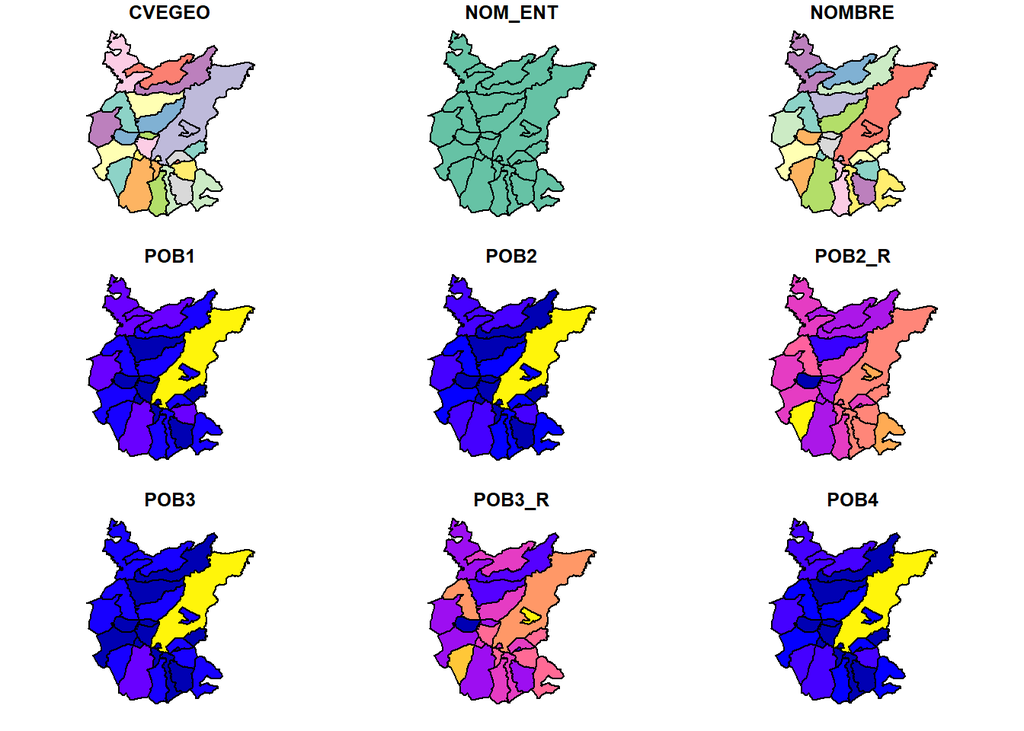

```r
plot(ixtlan)
```

```r
crs(ixtlan, proj = TRUE)
```

```
## [1] "+proj=utm +zone=14 +datum=WGS84 +units=m +no_defs"
```

#### 2.4 Cargar capa de puntos de muestreo

```r
sitios <- st_read("Sitios.shp")
dim(sitios)
```

```
## [1]  2 12
```

```r
names(sitios)
```

```
##  [1] "OBJECTID_1" "OBJECTID"   "ID"         "X"          "Y"
##  [6] "BUFF_DIST"  "ORIG_FID"   "Shape_Leng" "Sitio"      "Shape_Le_1"
## [11] "Shape_Area" "geometry"
```

```r
crs(ixtlan, proj = TRUE)
```

```
## [1] "+proj=utm +zone=14 +datum=WGS84 +units=m +no_defs"
```

#### 3. Importar rásters

#### 3.1 Modelo Digital de elevaciónn

```r
elevacion<-rast("DEM_ixtlan.tif")
elevacion
```

```
## class       : SpatRaster
## dimensions  : 5157, 4717, 1  (nrow, ncol, nlyr)
## resolution  : 15.26796, 15.26796  (x, y)
## extent      : 734697.3, 806716.2, 1890728, 1969464  (xmin, xmax, ymin, ymax)
## coord. ref. : WGS 84 / UTM zone 14N (EPSG:32614)
## source      : DEM_ixtlan.tif
## name        : DEM_ixtlan
## min value   :         68
## max value   :       3362
```

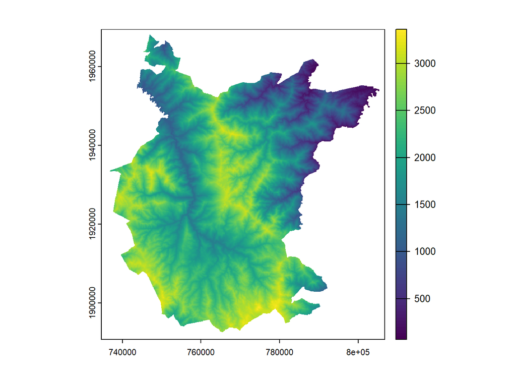

```r
plot(elevacion)
```

```r
summary(elevacion)
```

```
##    DEM_ixtlan
##  Min.   :  68
##  1st Qu.:1596
##  Median :2145
##  Mean   :2024
##  3rd Qu.:2545
##  Max.   :3356
##  NA's   :50181
```

```r
dim(elevacion)
```

```
## [1] 5157 4717    1
```

```r
class(elevacion)
```

```
## [1] "SpatRaster"
## attr(,"package")
## [1] "terra"
```

```r
elevacion$DEM_ixtlan
```

```
## class       : SpatRaster
## dimensions  : 5157, 4717, 1  (nrow, ncol, nlyr)
## resolution  : 15.26796, 15.26796  (x, y)
## extent      : 734697.3, 806716.2, 1890728, 1969464  (xmin, xmax, ymin, ymax)
## coord. ref. : WGS 84 / UTM zone 14N (EPSG:32614)
## source      : DEM_ixtlan.tif
## name        : DEM_ixtlan
## min value   :         68
## max value   :       3362
```

```r
crs(ixtlan, proj = TRUE)
```

```
## [1] "+proj=utm +zone=14 +datum=WGS84 +units=m +no_defs"
```

#### 3.2 Crear un hillshade a partir del modelo digital de elevación

##### Un Hillshade es una representación de un modelo digital de elevación (DEM) que utiliza sombreado para simular la luz del sol y crear un efecto tridimensional que muestra la topografía.

#### 3.2.1 Calcular atributos

##### La función terra::terrain() permite calcular la pendiente y la orientación a partir del DEM. Estas son esenciales para la capa Hillshade

```r
terrain_attributes <- terrain(elevacion, v = c("slope", "aspect"), unit = "radians")
slope <- terrain_attributes$slope
aspect <- terrain_attributes$aspect
```

##### La función terra::shade() utiliza la pendiente y la orientación calculadas, junto con un ángulo y una dirección del sol especificados, para crear el ráster de sombreado.

##### Define el ángulo y la dirección del sol (p. ej., 45 grados de elevación, 0 grados de acimut)

```r
hillshade <- shade(slope, aspect, angle = 45, direction = 0)
names(hillshade) <- "shades" # Renombrar
```

#### 3.2.2 Visualizar el sombreado

#### Graficar el sombreado directamente. Más adelante, se combinará con la capa DEM

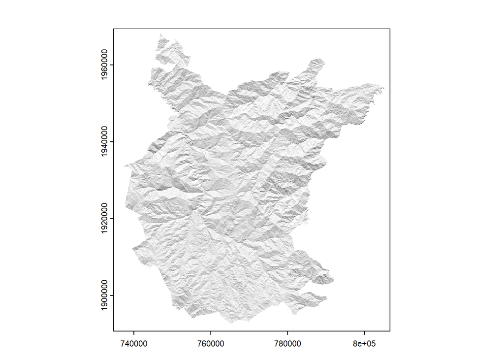

```r
plot(hillshade, col = gray.colors(256, start = 0, end = 1), legend = FALSE)
```

#### 3.3 Convertir el ráster de elevación en un data frame

```r
df_Ele<- as.data.frame(elevacion, xy = TRUE)
summary(df_Ele)
```

```
##        x                y             DEM_ixtlan
##  Min.   :736598   Min.   :1892628   Min.   :  68
##  1st Qu.:754569   1st Qu.:1912767   1st Qu.:1595
##  Median :766325   Median :1928997   Median :2145
##  Mean   :766619   Mean   :1928450   Mean   :2024
##  3rd Qu.:777929   3rd Qu.:1944173   3rd Qu.:2545
##  Max.   :805228   Max.   :1968281   Max.   :3362
```

```r
class(df_Ele)
```

```
## [1] "data.frame"
```

#### 4. Visualizaciones

#### 4.1 Visualizar ráster

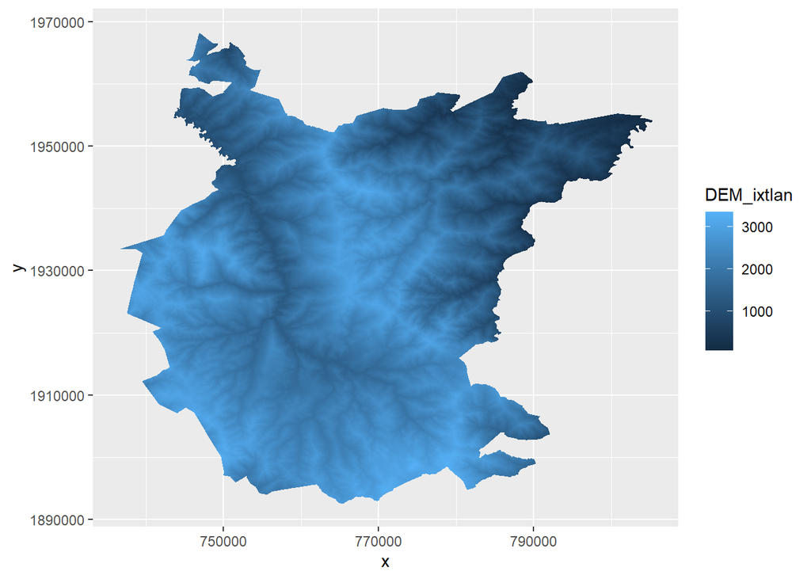

```r
ggplot(data = df_Ele,aes(x = x,
                         y = y)) +
  geom_raster(aes(fill = DEM_ixtlan))
```

#### 4.1.2 Creando paleta propia

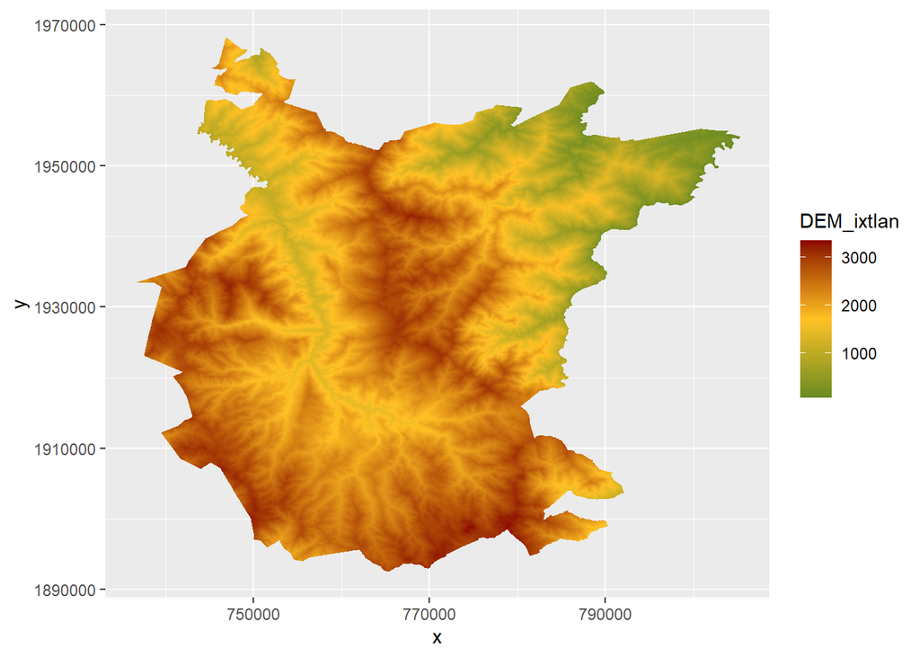

```r
ggplot(data = df_Ele,aes(x = x,
                         y = y)) +
  geom_raster(aes(fill = DEM_ixtlan))+
  scale_fill_gradientn(colours = c("#698B22", "#FFC125","darkred"))
```

#### 4.2 Añadir capas vectoriales

##### Crear paleta de color para la capa de sitios

```r
pal_col <- c('darkorchid4', 'royalblue4')
```

#### 4.2.1 Añadir 2 Capas vectoriales

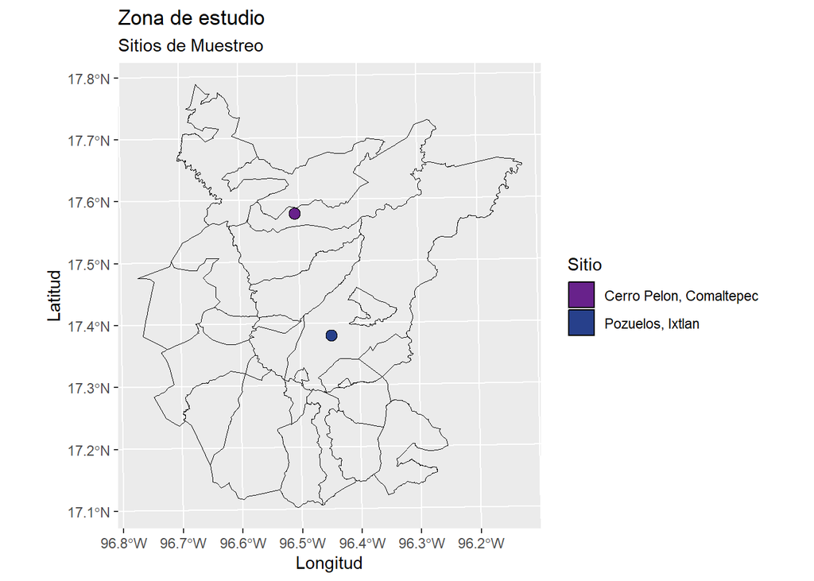

```r
ggplot(data =ixtlan) +
  geom_sf(color='black', fill=NA) +
  xlab("Longitud") + ylab("Latitud") +
  ggtitle("Zona de estudio",
          subtitle = "Sitios de Muestreo")+
 geom_sf(data=sitios, color = 'black', aes(fill=Sitio))+
  scale_fill_manual(values=pal_col)
```

#### Mapa del País con estado de Oaxaca

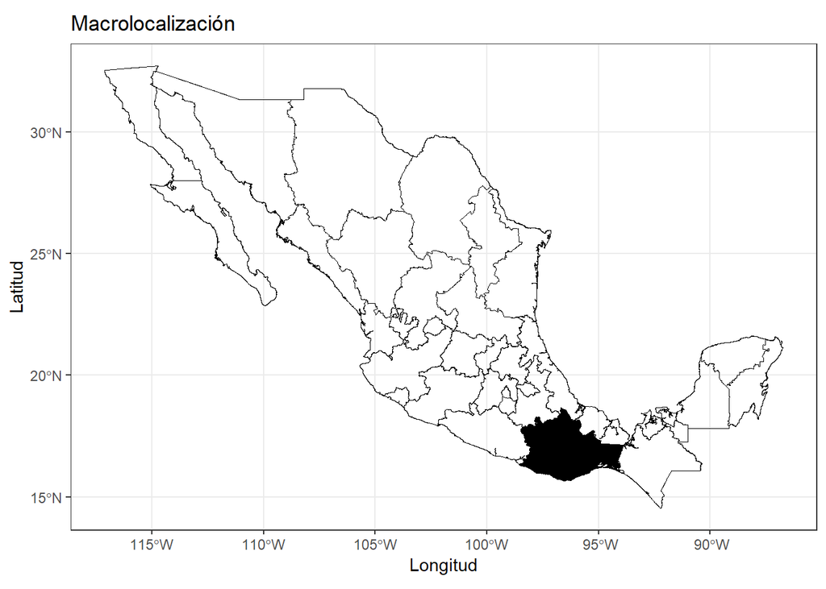

```r
mv1 <- ggplot(data =Mexico) +
  geom_sf(color='black', fill=NA) +
  xlab("Longitud") + ylab("Latitud") +
  ggtitle("Macrolocalización")+
  geom_sf(data=oaxaca, color = 'black', fill='black')+
  theme_bw()
mv1
```

#### Mapa de Oaxaca con el distrito de Ixtlán

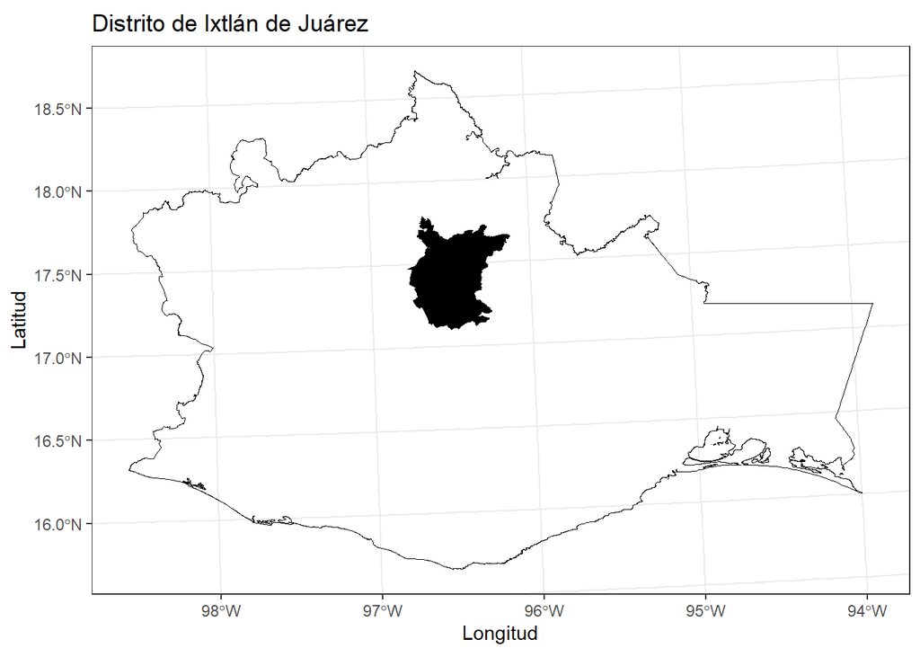

```r
mv2 <- ggplot(data =oaxaca) +
  geom_sf(color='black', fill=NA) +
  xlab("Longitud") + ylab("Latitud") +
  ggtitle("Distrito de Ixtlán de Juárez", )+
  theme(plot.title = element_text(size = 12))+
  geom_sf(data=ixtlan, color = 'black', fill='black')+
  theme_bw()
mv2
```

#### 4.3 Añadir 3 capas 2 raster y 1 vectorial

##### Añadir rosa de los vientos y escala

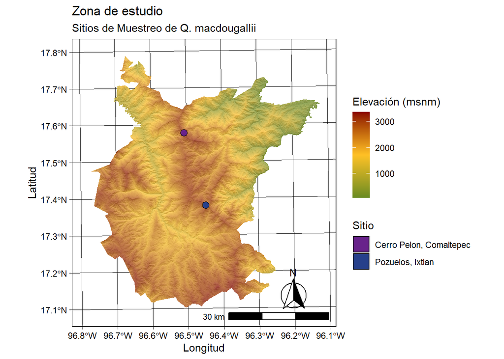

```r
m <-ggplot()+
  geom_raster(data = df_Ele,aes(x = x,
                                   y = y,fill = DEM_ixtlan))+
  scale_fill_gradientn(colours = c("#698B22", "#FFC125","darkred"), name = "Elevación (msnm)")+
  xlab("Longitud") + ylab("Latitud") +
  ggtitle("Zona de estudio",
          subtitle = "Sitios de Muestreo de Q. macdougallii")+
  annotation_scale(location = "br", width_hint = 0.5) + # añadir escala
  annotation_north_arrow(location = "br", which_north = "true",  # añadir rosa de los vientos
                         pad_x = unit(0.75, "cm"), pad_y = unit(0.5, "cm"),
                         style = north_arrow_fancy_orienteering)+
  new_scale_fill()+ # Permite agregar una nueva paleta de color para la siguiente capa
  geom_spatraster(data = hillshade, aes(fill = shades), alpha = 0.3) + # Ajustar la transparencia con alpha
  scale_fill_gradientn(colors = hcl.colors(100, "Grays"), na.value = NA, guide = "none") +
  new_scale_fill()+ # Permite agregar una nueva paleta de color para la siguiente capa
  geom_sf(data=sitios, color = 'black', aes(fill=Sitio))+
  scale_fill_manual(values=pal_col)+
  theme_linedraw()

m
```

#### 5. Mapa completo

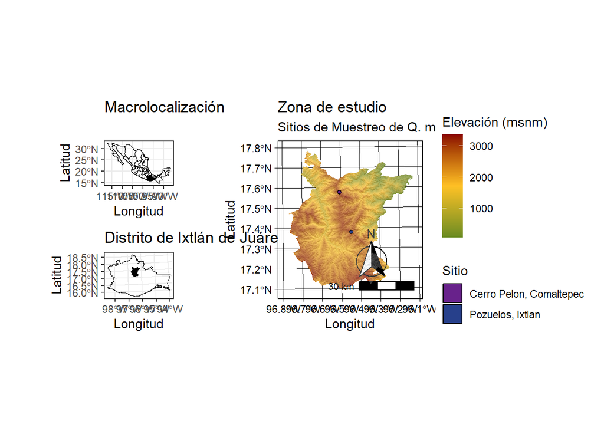

```r
mapa <- ((mv1 / mv2 + plot_layout(guides = 'keep')) | m) + plot_layout(guides = 'collect')
mapa
```

#### 5.1 Guardar mapa

```r
ggsave("Mapa_Final.jpg", plot = mapa, width = 11, height = 6,dpi = 300)
```